# Rpub test

Kevin Spring

11/15/2014

This is just to test that publishing to Rpubs is working.

## Introduction

The purpose of this project is to predict a word a user is typing and also predict a successive word after a word is typed. The final product will be a web application that allows a user to input text into a text field. The application will predict what word they are typing and display a few words that are predicted. The user can click on these words for faster user input if the words are correctly predicted or continue to type. As the user continues to input characters the application will continue to display predicted words on the sequence of character inputs. After a word is inputted or selected by the user, the application will predict what next word the user will input and display a list of possible predicted words or phrases. The user can select the application predicted text or continue to input characters.

## Data Manipulation

The data used in this analysis is text from english language twitter feeds, blogs, and news. The twitter, news, and blog text data has 2,360,148, 1,010,242, and 899,288 lines of code, respectively.

The training data set was limited to 50,000, 20,000, and 20,000 lines of code for the twitter, news, and blog text data, respectively. This training set was selected by taking a random sample of each of the twitter, news, and blog text data sets. Before we can accuratly assess how many words are in each line of text the data needs to be cleaned. I used the R programming language with the `tm` package to analyze the text data.

## Results

The first step is to remove any non-Latin characters in the data set. Althought this data is classified as English, there is non-Latin characters in the data. The characters removed includes emoticons, Chinese hanzi, and Japanese kana. Arabic numbers are also removed from the training data. There were a total of 85521 terms in the combined twitter, news, and blog text data.

A further reduction of words such as onomatopoeias and profanity filters the data set to 2108 terms. Profanity is commonly used in the corpus but serves no prediction value to this project. The same profanity word can be used as a verb, noun, adverb, or adjective and thus prediction is limited for these words. As a user interface tool, showing profanity for predicted words if the user did not want to see may cause the user to use a competitor’s product. If the user uses profanity then those words can be added to the dictionary of the final tool to accurately predict and suit the user’s language style.

As shown in Table 1, the ten most common terms are stop words. Table 2 shows the ten most common words with stop words removed from the corpus. Unlike most test data analysis, I will be keeping stop words in the corpus. Term frequency was measured using the number of times a term is used in a document.

### Table 1: Ten most frequent terms including stop words

```
##      word  freq
## the   the 99537
## and   and 50196
## for   for 23173
## that that 21941
## you   you 20166
## with with 14789
## was   was 13222
## this this 11674
## have have 11381
## are   are 10450
```

```
##      word freq
## will will 6733
## just just 6380
## said said 6094
## one   one 6089
## can   can 5247
## get   get 4805
## time time 4552
## new   new 4113
## good good 3817
## now   now 3788
```

### Figure 1: Word cloud of corpus

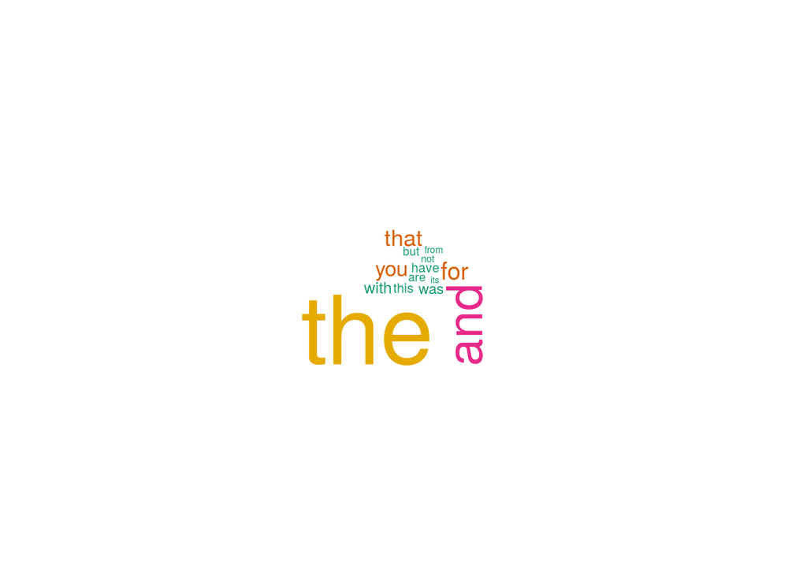

### Figure 2: Word cloud of corpus without stop words

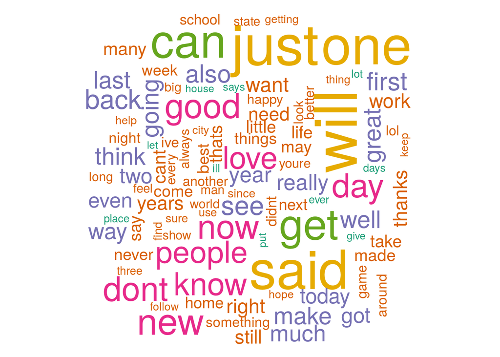

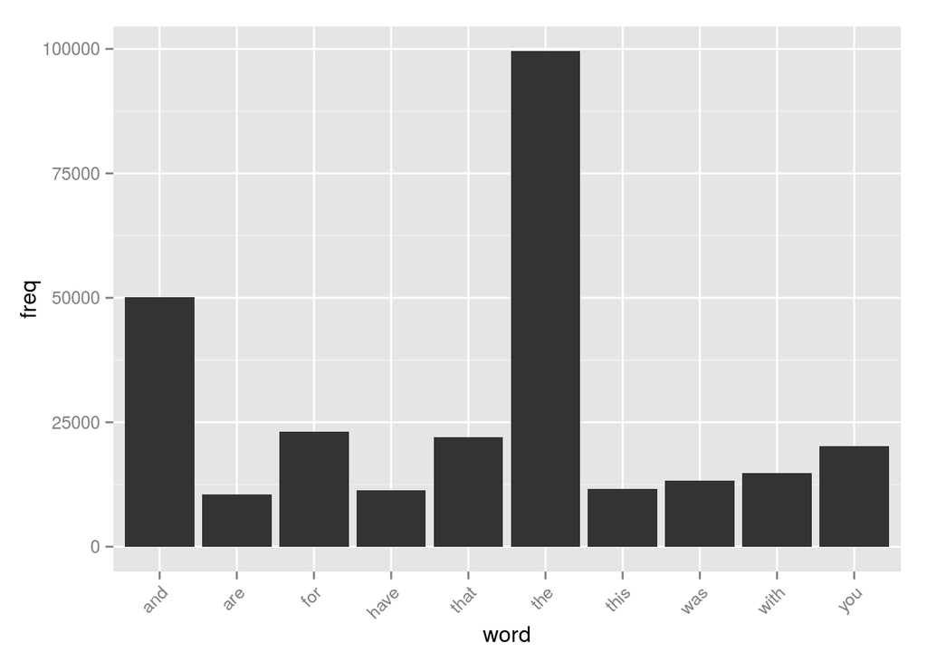

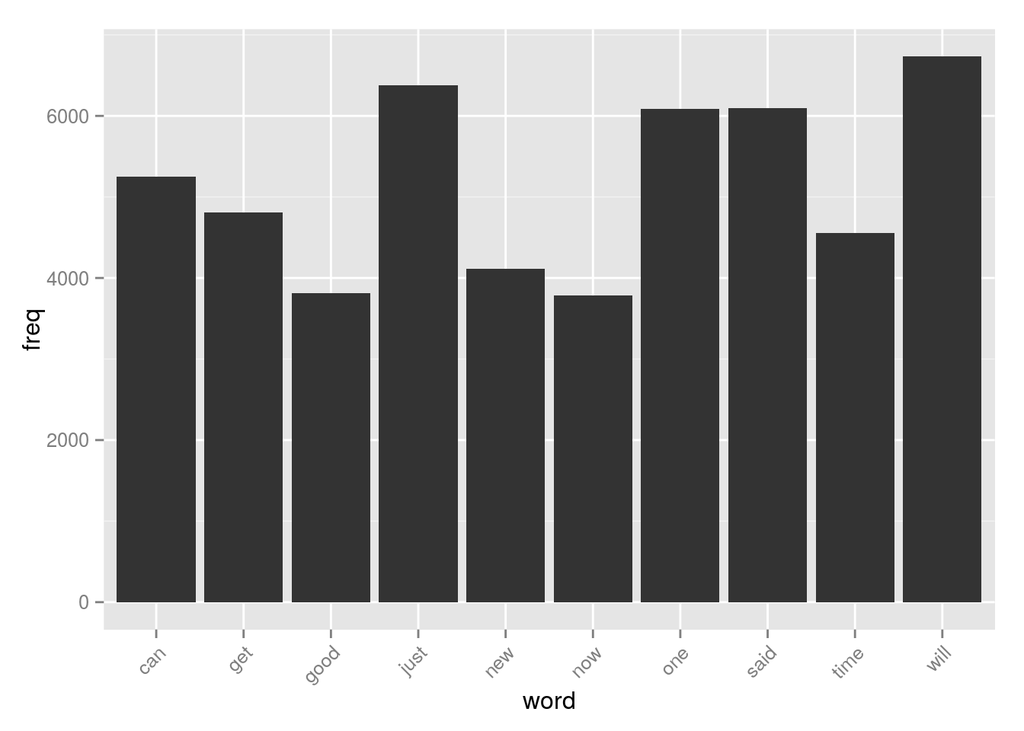

### N-gram tokenization

A bigram is two words that appear in a sequence. For example, “happy birthday” would be a bigram. Table 3 shows the top ten bigrams in the corpus after sparse terms were removed.

#### Ten most common bigrams

```
##                    word freq
## right now     right now  501
## new york       new york  434
## dont know     dont know  425
## last year     last year  383
## cant wait     cant wait  382
## last night   last night  324
## years ago     years ago  301
## last week     last week  296
## high school high school  290
## im going       im going  288
```